# Retail Forecasting Project

Mohammad Nadzmi Ag Thomas

2023-05-19

# Introduction

In this report, we will forecast real time series using ARIMA and ETS models. We will begin by analysing the data. Secondly, we will examine the stationarity of the data, and how the data can be transformed into stationary data (for ARIMA model). Thirdly, we will perform model selection for both ARIMA and ETS method. Then, we will run a model diagnostic on one of ARIMA and one of ETS model. Finally, we will re-train the model on full data, and perform 2 years forecasting and compare the performance against available online ABS data.

# Statistical Features Analysis

Let’s first plot our series and see if we can roughly identify any pattern.

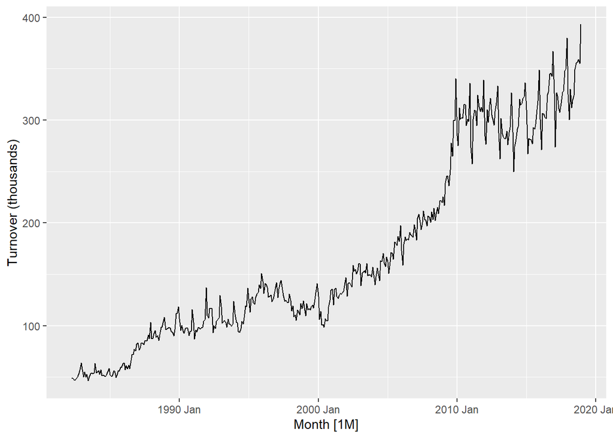

```r
myseries |> autoplot(Turnover) + labs(y = "Turnover (thousands)")
```

> From the plot above, it’s apparent that our series is non-stationary as it shows upward trend and a possible seasonality.

#### Checking Seasonality

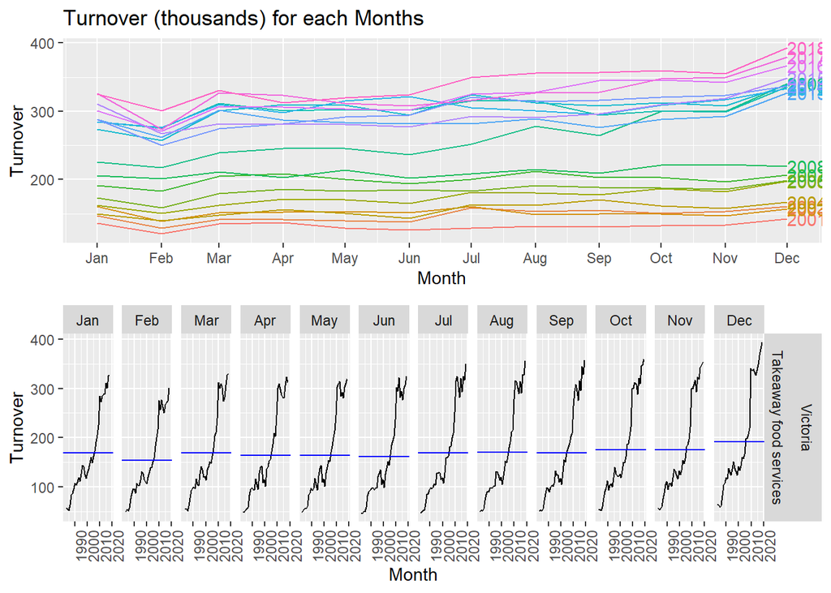

```r
p1 <- myseries |>
  filter(year(Month) > 2000) |>
  gg_season(Turnover, labels = "right") +
  labs(title = "Turnover (thousands) for each Months", y = "Turnover")

p2 <- myseries |> gg_subseries(Turnover)

gridExtra::grid.arrange(p1, p2)
```

> The first plot shows how Turnover vary montly for different years (line colour), and the second plot is similar to this, except we will plot the annual change of Turnover for each month. Both of these plot are useful to capture the relationship between Turnover and Month. From first plot, there’s a spike of Turnover every December (especially on recent observation), and from the second plot, the mean (blue line) of Turnover during december is higher than the rest of the month. One of the contributing factor of this could be due to Christmas season and many special (such as black friday). This spike indicate the seasonality of our timeseries.

### Checking Trend

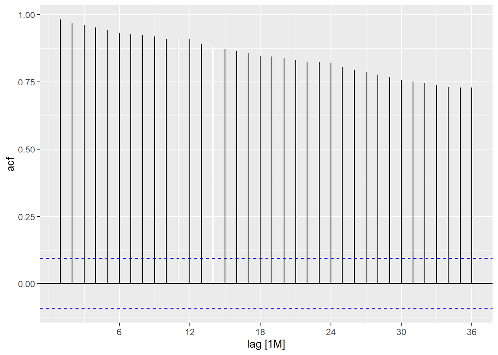

```r
myseries |>
  ACF(Turnover, lag_max = 36) |>
  autoplot()
```

> The plot above is an ACF plot, and it measures how observation (Turnover) is correlated to previous values, this is helpful for checking trend and seasonality. From the ACF plot above, we have a slowly decaying ACF and a large positve value on lag 1. This can be indication of trend, and also notice that there’s a slight bump every 12 lags (12, 24, 36) which may indicate annual seasonality.

### STL Decomposition

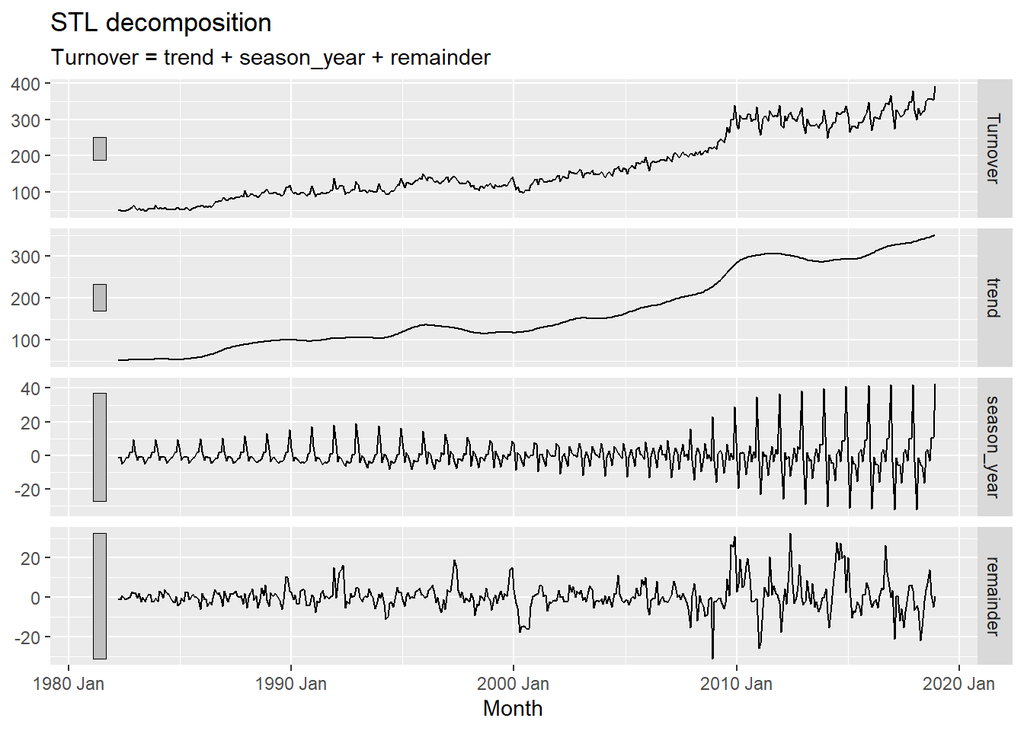

```r
myseries |>
  model(stl = STL(Turnover, robust = TRUE)) |>
  components() |>
  autoplot()
```

> STL decomposes timeseries into Trend (moving average), Seasonality (timeseries - trend), and Remainder (timeseries - trend - seasonality). Looking at the trend component, there’s a clear upward trend. From seasonality component, there’s a consistent spike and through indicating seasonality, and it should be noted that there’s an increasing variation from 2010 onwards. Similar to the seasonality, the variation of remainder also increased from 2010 onwards.

# Data Transformation

Since we will be using ARIMA model for forecasting, we want to make sure our data can be transformed into stationary timeseries. From the analysis done on previous part, we know that trend and seasonality exist in our data. Now we wanna find out if differencing is required or not. Also, since the variation of seasonality components is increasing over the last few years, we will scale our target (Turnover) using logarithm to stabilize the variance.

```r
# Check if differencing is required, if so what order of differencing
myseries |> features(log(Turnover), unitroot_ndiffs)
```

```
## # A tibble: 1 × 3
##   State    Industry               ndiffs
##   <chr>    <chr>                   <int>
## 1 Victoria Takeaway food services      1
```

> We get reported value of ndiffs = 1 from KPSS unitroot test. Hence, first order differencing is required.

```r
# Now let's check if seasonal differencing is also required (after first differencing is applied)
myseries |> features(log(Turnover) |> difference(lag = 1), unitroot_nsdiffs)
```

```
## # A tibble: 1 × 3
##   State    Industry               nsdiffs
##   <chr>    <chr>                    <int>
## 1 Victoria Takeaway food services       1
```

> We get reported value of nsdiffs = 1 for seasonal differencing. Hence, first order seasonal differencing is required.

# Model Selection

```r
# The yearmonth (index) of last 24 (months) observation
last_24 <- myseries$Month[nrow(myseries) - 24]

# Split the data into training and testing
train_data <- myseries |> filter(Month <= last_24)
test_data <- myseries |> filter(Month > last_24)
```

### Finding ARIMA model

From previous finding, we know that a first order differencing and a first order seasonal differencing are required to keep our data stationary. Therefore, $ARIMA(p,1,q)(P,1,Q)_{12}$ will be a good choice as our forecasting model. Now we will find the best model by testing different parameters.

#### Parameters Selection

We use ACF and PACF plot to find the MA and the AR components respectively.

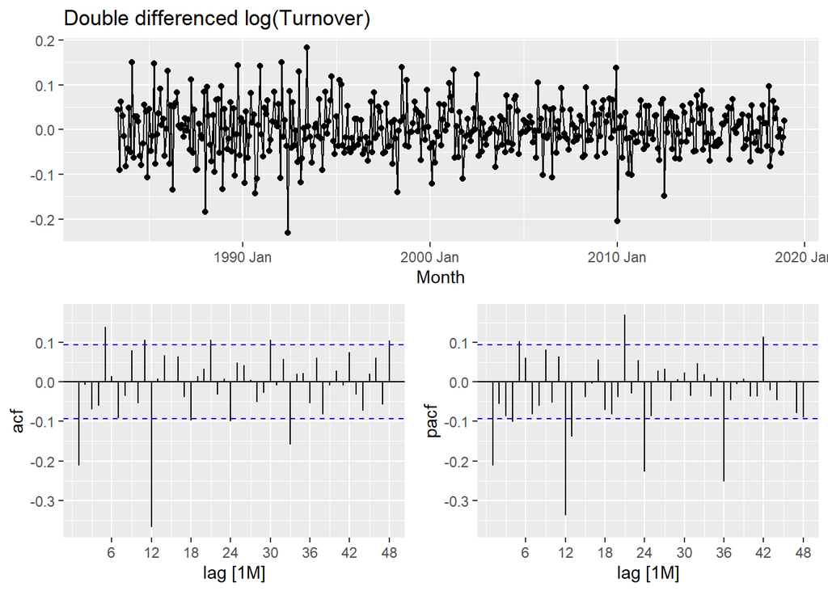

```r
myseries |> gg_tsdisplay(difference(log(Turnover), 12) |> difference(), plot_type = "partial", lag = 48) +
  labs(title = "Double differenced log(Turnover)", y = "")
```

**Here are few potential ARIMA model:**

- Looking at our ACF, the significant spike at lag 5 suggest a $MA(5)$ for the non-seasonal component, and the significant spike at lag 12 suggest a $MA(1)$ for the seasonal component. This give us a first potential model of $ARIMA(0,1,5)(0,1,1)_{12}$
- Looking at our PACF, the significant spike at lag 1 suggest an $AR(1)$ for the non-seasonal component, and the significant spike at lag 12, 24, 36 suggest an $AR(3)$ for the seasonal component. This give us another potential model of $ARIMA(1,1,0)(3,1,0)_{12}$
- We also included $ARIMA(1,0,5)(3,1,0)_{12}$ with drift to capture trend in data. Here we remove the first order differencing as the trend is captured using the drift
- We will also include automatically selected model for comparison. We will do this by setting stepwise=FALSE and approximation=FALSE to find the model with the lowest AICc value.

```r
ARIMA_fit <- train_data |>
  model(
    Arima015011 = ARIMA(log(Turnover) ~ pdq(0, 1, 5) + PDQ(0, 1, 1, period = 12)),
    Arima110310 = ARIMA(log(Turnover) ~ pdq(1, 1, 0) + PDQ(3, 1, 0, period = 12)),
    ArimaDrift = ARIMA(log(Turnover) ~ 1 + pdq(1, 0, 5) + PDQ(3, 1, 0, period = 12)),
    Auto = ARIMA(log(Turnover), stepwise = FALSE, approx = FALSE)
  )
```

#### AICc Comparison

```r
ARIMA_fit |>
  pivot_longer(Arima015011:Auto,
    names_to = ".model",
    values_to = "Params"
  ) |>
  select(.model:Params) |>
  left_join(glance(ARIMA_fit) |> select(.model:BIC)) |>
  arrange(AICc)
```

```
## # A mable: 4 x 7
## # Key:     .model [4]
##   .model                             Params  sigma2 log_lik    AIC   AICc    BIC
##   <chr>                             <model>   <dbl>   <dbl>  <dbl>  <dbl>  <dbl>
## 1 Auto   <ARIMA(1,0,1)(0,1,1)[12] w/ drift> 0.00220    659. -1309. -1309. -1289.
## 2 Arima…          <ARIMA(0,1,5)(0,1,1)[12]> 0.00222    657. -1301. -1301. -1273.
## 3 Arima… <ARIMA(1,0,5)(3,1,0)[12] w/ drift> 0.00230    657. -1291. -1290. -1247.
## 4 Arima…          <ARIMA(1,1,0)(3,1,0)[12]> 0.00240    644. -1278. -1277. -1258.
```

> The AICc quantifies the balance between model’s goodness of fit and its complexity (or number of parameters). Model with low AICc tends to perform better than model with high AICc. Here, ARIMA model found automatically gives the best AICc, however we should also use other metrics before deciding on which model to use.

#### RMSE Comparison

```r
ARIMA_fit |>
  forecast(h = 24) |>
  accuracy(test_data) |>
  select(.model, RMSE:MAPE) |>
  arrange(RMSE)
```

```
## # A tibble: 4 × 5
##   .model       RMSE   MAE   MPE  MAPE
##   <chr>       <dbl> <dbl> <dbl> <dbl>
## 1 Arima110310  10.5  8.77 -2.24  2.68
## 2 ArimaDrift   16.8 14.9  -4.41  4.49
## 3 Arima015011  20.5 18.6  -5.70  5.70
## 4 Auto         25.3 23.5  -7.13  7.13
```

> RMSE measure the prediction error of forecasted value against true value, it is a measure of model’s predictive power. Alghough, ARIMA model found automatically give the lowest AICc, it return the highest RMSE after testing it on test set, and therefore might be a bad model choice.

### Finding ETS model

Since we know the data has seasonality and trend, it will make sense to use Holt-Winter’s method which capture trend and seasonality. However, for the sake of comparison we will use simple exponential smoothing, Holt’s Linear method, Holt-Winter’s method and automatically selected model.

```r
ETS_fit <- train_data |>
  model(
    Simple = ETS(Turnover ~ error("A") + trend("N") + season("N")),
    HoltLinear = ETS(Turnover ~ error("A") + trend("A") + season("N")),
    HoltLinearDamped = ETS(Turnover ~ error("A") + trend("Ad") + season("N")),
    HoltWinterAdd = ETS(Turnover ~ error("A") + trend("A") + season("A")),
    HoltWinterMul = ETS(Turnover ~ error("M") + trend("A") + season("M")),
    HoltWinterDamped = ETS(Turnover ~ error("M") + trend("Ad") + season("M")),
    Auto = ETS(Turnover)
  )
```

#### AICc Comparison

```r
ETS_fit |>
  pivot_longer(Simple:Auto,
    names_to = ".model",
    values_to = "Params"
  ) |>
  select(.model:Params) |>
  left_join(glance(ETS_fit) |> select(.model:BIC)) |>
  arrange(AICc)
```

```
## # A mable: 7 x 7
## # Key:     .model [7]
##   .model                  Params    sigma2 log_lik   AIC  AICc   BIC
##   <chr>                  <model>     <dbl>   <dbl> <dbl> <dbl> <dbl>
## 1 HoltWinterDamped <ETS(M,Ad,M)>   0.00226  -2032. 4101. 4102. 4173.
## 2 Auto             <ETS(M,Ad,M)>   0.00226  -2032. 4101. 4102. 4173.
## 3 HoltWinterMul     <ETS(M,A,M)>   0.00260  -2064. 4162. 4163. 4230.
## 4 HoltWinterAdd     <ETS(A,A,A)>  75.7      -2152. 4338. 4339. 4406.
## 5 HoltLinear        <ETS(A,A,N)> 143.       -2290. 4591. 4591. 4611.
## 6 Simple            <ETS(A,N,N)> 144.       -2293. 4592. 4592. 4604.
## 7 HoltLinearDamped <ETS(A,Ad,N)> 145.       -2292. 4597. 4597. 4621.
```

> The model find automatically is the same as Holt Winter’s Damped, and both of them have the lowest AICc value, meaning they have a good balance between goodness of fit and complexity.

#### RMSE Comparison

```r
ETS_fit |>
  forecast(h = 24) |>
  accuracy(test_data) |>
  select(.model, RMSE:MAPE) |>
  arrange(RMSE)
```

```
## # A tibble: 7 × 5
##   .model            RMSE   MAE     MPE  MAPE
##   <chr>            <dbl> <dbl>   <dbl> <dbl>
## 1 HoltWinterAdd     14.8  11.3  -2.97   3.50
## 2 Auto              15.6  13.2  -0.237  3.98
## 3 HoltWinterDamped  15.6  13.2  -0.237  3.98
## 4 HoltWinterMul     26.0  21.9  -6.88   6.88
## 5 Simple            34.1  28.0  -7.37   8.80
## 6 HoltLinearDamped  35.9  30.6  -8.52   9.61
## 7 HoltLinear        39.2  34.7 -10.1   10.9
```

> Holt Winter’s Damped have the second lowest RMSE value, but very close to the first one (Holt Winter’s Additive). Therefore, Holt Winter’s Damped will be a good model choice for forecasting as it has both low RMSE and AICc.

# Model Diagnostic

Now we will run diagnostic on one ARIMA model and one ETS model. For ARIMA model, we will choose $ARIMA(1,0,5)(3,1,0)_{12}$ with drift which gives the second lowest RMSE, and the second largest AICc. And for ETS model, we will choose $Holt\ Winter's\ Damped$ which gives the second lowest RMSE and the lowest AICc.

### Diagnostic of ARIMA

#### Estimated Parameters

```r
ARIMA_selected <- ARIMA_fit |> select(ArimaDrift)
ARIMA_selected |> report()
```

```
## Series: Turnover
## Model: ARIMA(1,0,5)(3,1,0)[12] w/ drift
## Transformation: log(Turnover)
##
## Coefficients:
##          ar1      ma1     ma2      ma3      ma4     ma5     sar1     sar2
##       0.9343  -0.2014  0.0340  -0.0419  -0.0481  0.1740  -0.5285  -0.3874
## s.e.  0.0241   0.0529  0.0533   0.0535   0.0526  0.0539   0.0500   0.0527
##          sar3  constant
##       -0.2493    0.0077
## s.e.   0.0497    0.0021
##
## sigma^2 estimated as 0.002305:  log likelihood=656.51
## AIC=-1291.01   AICc=-1290.34   BIC=-1246.97
```

#### Residual Diagnostic

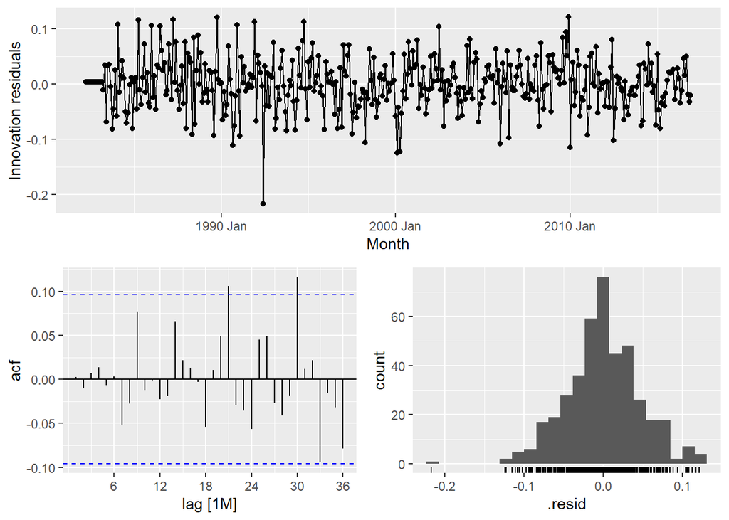

```r
ARIMA_selected |> gg_tsresiduals(lag = 36)
```

```r
# Perform Ljung-Box test
ARIMA_selected |>
  augment() |>
  features(.innov, ljung_box, lag = 24, dof = 4)
```

```
## # A tibble: 1 × 3
##   .model     lb_stat lb_pvalue
##   <chr>        <dbl>     <dbl>
## 1 ArimaDrift    16.5     0.684
```

> Ljung-Box test is a statistical test used to assess whether residuals are white noise or not. It uses the autocorrelations of residuals to perform hypothesis testing, where null hypothesis is that there’s no autocorrelation in the residuals (i.e. the residuals are whtie noise). The large p-value (p > 0.05) confirm that the residuals are indeed white noise.

#### Forecast (2 years)

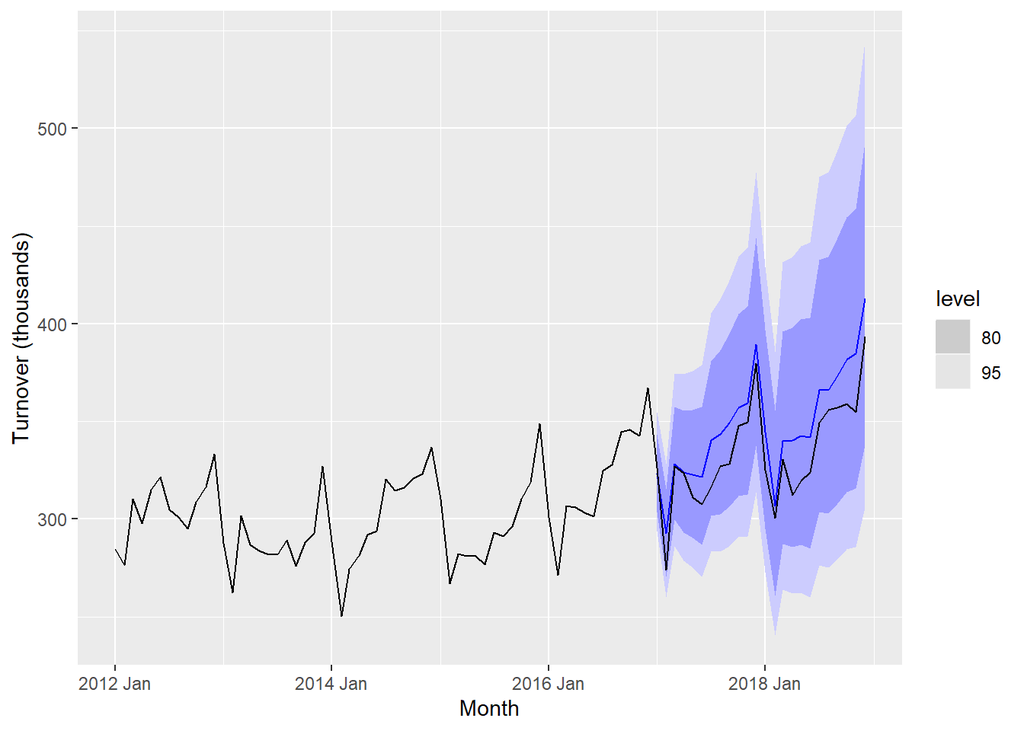

```r
# Only show the observation after year 2012
# to keep the plot clean
After2012 <- myseries |>
  filter(year(Month) >= 2012) |>
  select(-c(State, Industry))

ARIMA_selected |>
  forecast(h = 24) |>
  autoplot(After2012) + labs(y = "Turnover (thousands)")
```

> The plot above show the forecasted values (blue line) against the true values (black line) from 2017 Jan to 2018 Dec. The blue shaded regions show the 80% and 95% prediction intervals. The plot is useful to see how good our model in forecasting future data, and as can be seen our ARIMA model forecast the data relatively well.

### Diagnostic of ETS

#### Estimated Parameters

```r
ETS_selected <- ETS_fit |> select(HoltWinterDamped)

ETS_selected |> report()
```

```
## Series: Turnover
## Model: ETS(M,Ad,M)
##   Smoothing parameters:
##     alpha = 0.7519967
##     beta  = 0.003430003
##     gamma = 0.000106193
##     phi   = 0.9733574
##
##   Initial states:
##      l[0]      b[0]     s[0]     s[-1]    s[-2]    s[-3]   s[-4]    s[-5]
##  49.86206 0.2793564 1.001125 0.9349281 1.025083 1.114239 1.01949 1.019167
##      s[-6]     s[-7]     s[-8]     s[-9]    s[-10]   s[-11]
##  0.9875176 0.9903867 0.9875841 0.9476672 0.9843334 0.988479
##
##   sigma^2:  0.0023
##
##      AIC     AICc      BIC
## 4100.544 4102.262 4173.139
```

> The report above show the parameters for fitted Holt Winter’s Damped method. The formulation will be quite tedious, and therefore for further information please visit [here](https://otexts.com/fpp3/holt-winters.html).

#### Residual Diagnostic

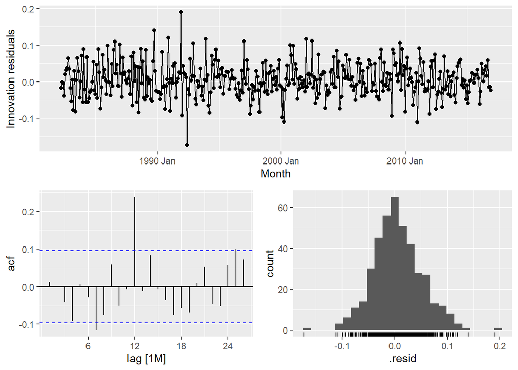

```r
ETS_selected |> gg_tsresiduals()
```

> From the residual plot on the top, the lack of observable pattern can be an indication of a white noise residuals. The histogram shown is also relatively normal with no skew. However, there’s one really significant spike (lag 12) out of 24. Therefore, just to be sure, we will perform Ljung-Box test.

```r
ETS_selected |>
  augment() |>
  features(.innov, ljung_box, lag = 24, dof = 4)
```

```
## # A tibble: 1 × 3
##   .model           lb_stat lb_pvalue
##   <chr>              <dbl>     <dbl>
## 1 HoltWinterDamped    54.0 0.0000581
```

> From the small p-value (p < 0.05), we can’t conclude that residuals are white noise. Therefore, there might be underlying patterns and structured not being captured by our model.

#### Forecast (2 years)

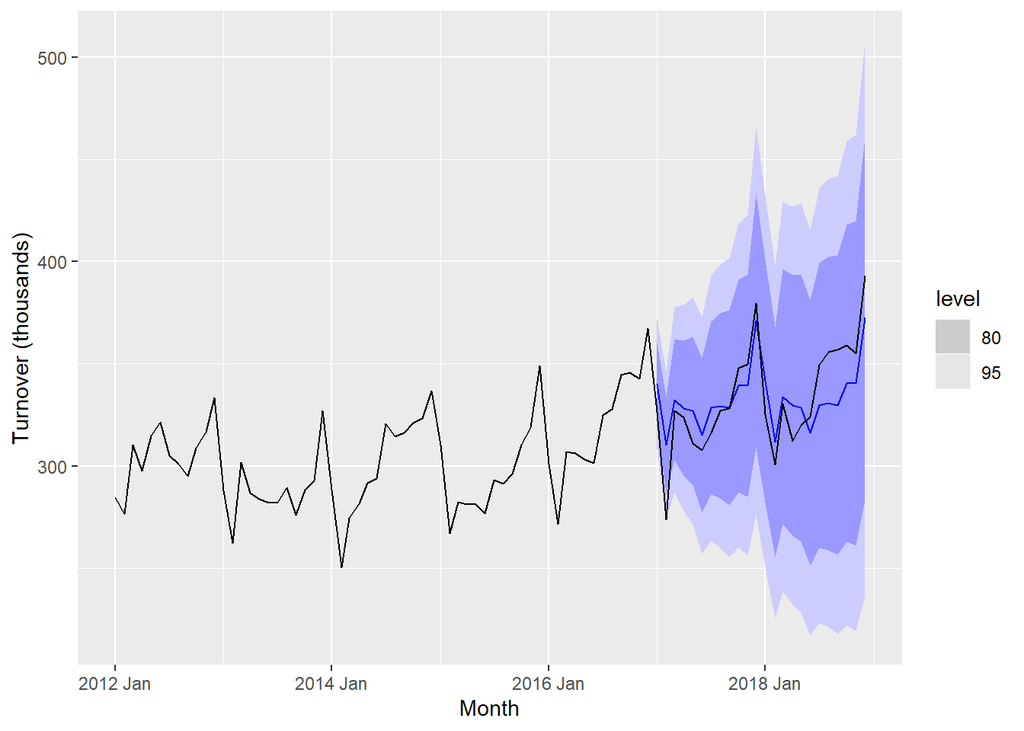

```r
ETS_selected |>
  forecast(h = 24) |>
  autoplot(After2012) + labs(y = "Turnover (thousands)")
```

> The plot show how our ETS model’s forecasted value (blue line) fit against the true value (black line). As can be seen our model fit rather well.

# Model Comparison

### Predictive Errors Comparison

```r
ARIMA_selected |>
  mutate(
    HoltWinterDamped = ETS_selected |> pull()
  ) |>
  forecast(h = 24) |>
  accuracy(test_data) |>
  select(.model, RMSE:MAPE) |>
  arrange(RMSE)
```

```
## # A tibble: 2 × 5
##   .model            RMSE   MAE    MPE  MAPE
##   <chr>            <dbl> <dbl>  <dbl> <dbl>
## 1 HoltWinterDamped  15.6  13.2 -0.237  3.98
## 2 ArimaDrift        16.8  14.9 -4.41   4.49
```

> Using few predictive errors obtained from forecasting against test set, it’s clear that Holt Winter’s Damped method give a better forecast. Holt Winter’s Damped method gives lower RMSE, MAE and MAPE while ArimaDrift only give lower MPE.

### Out-Of-Sample Forecasting

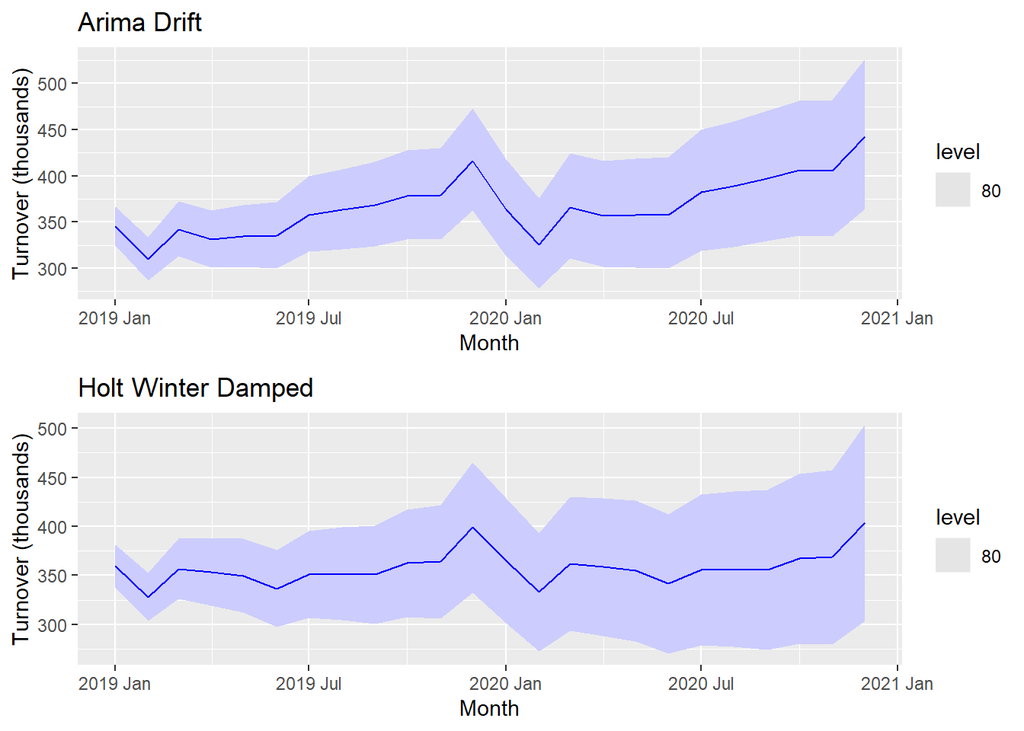

```r
# Retrain the chosen models on the wholedataset
FULL_fit <- myseries |>
  model(
    ArimaDrift = ARIMA(log(Turnover) ~ 1 + pdq(1, 0, 5) + PDQ(3, 1, 0, period = 12)),
    HoltWinterDamped = ETS(Turnover ~ error("M") + trend("Ad") + season("M"))
  )

# Forecast two years out-of-sample
Two_years_forecast <- FULL_fit |>
  forecast(h = 24)

# ARIMA prediction plot
p1 <- Two_years_forecast |>
  filter(.model == "ArimaDrift") |>
  autoplot(level = 80) +
  labs(title = "Arima Drift", y = "Turnover (thousands)")

# ETS prediction plot
p2 <- Two_years_forecast |>
  filter(.model == "HoltWinterDamped") |>
  autoplot(level = 80) + labs(title = "Holt Winter Damped", y = "Turnover (thousands)")

# Show the plot
grid.arrange(p1, p2)
```

> Both ARIMA and ETS model seems to produce similar point forecast by looking at the blue lines. However, the ETS model seems to have wider forecasting interval (i.e. less confidence).

**Now let’s compare our out-of-sample forecast against up to date data**

```r
# Getting up-to-date data from ABS
seriesID <- unique(myseries["Series ID"])[[1]]
newseries <- read_abs(series_id = seriesID)

# Cleaning the data
newseries <- newseries |>
  select(value, date) |>
  mutate(State = "Victoria", Industry = "Takeaway food services", date = yearmonth(date)) |>
  as_tsibble(index = date, key = c(State, Industry)) |>
  arrange(date)

# Getting new two years observation following our original data
last_month <- myseries |>
  tail(1) |>
  pull(Month)

# Test set for our out of sample forecast
test_set <- filter(newseries, date > last_month)[1:24, ] |> rename("Month" = date, "Turnover" = value)

# Measure the errors
Two_years_forecast |>
  accuracy(test_set) |>
  select(.model, RMSE:MAPE) |>
  arrange(RMSE)
```

```
## # A tibble: 2 × 5
##   .model            RMSE   MAE   MPE  MAPE
##   <chr>            <dbl> <dbl> <dbl> <dbl>
## 1 HoltWinterDamped  31.8  21.3 -5.96  6.88
## 2 ArimaDrift        42.5  29.1 -8.64  9.25
```

> Holt Winter’s Damped method perform better than our Seasonal Arima with Drift as can be seen across the different error measure. However, both models have surprisingly twice as large as the RMSE from previous in-sample forecast.

### Data Limitation

Since we are forecasting 2 years period from 2019 Jan to 2020 Dec, we will also be forecasting for period where Covid-19 pandemic is undergoing (starting from 2020 Jan). Because of this, we will expect our models’ goodness of fit to worsen after 2020 Jan (which explain the previous finding). And this is apparent by looking at the graph below.

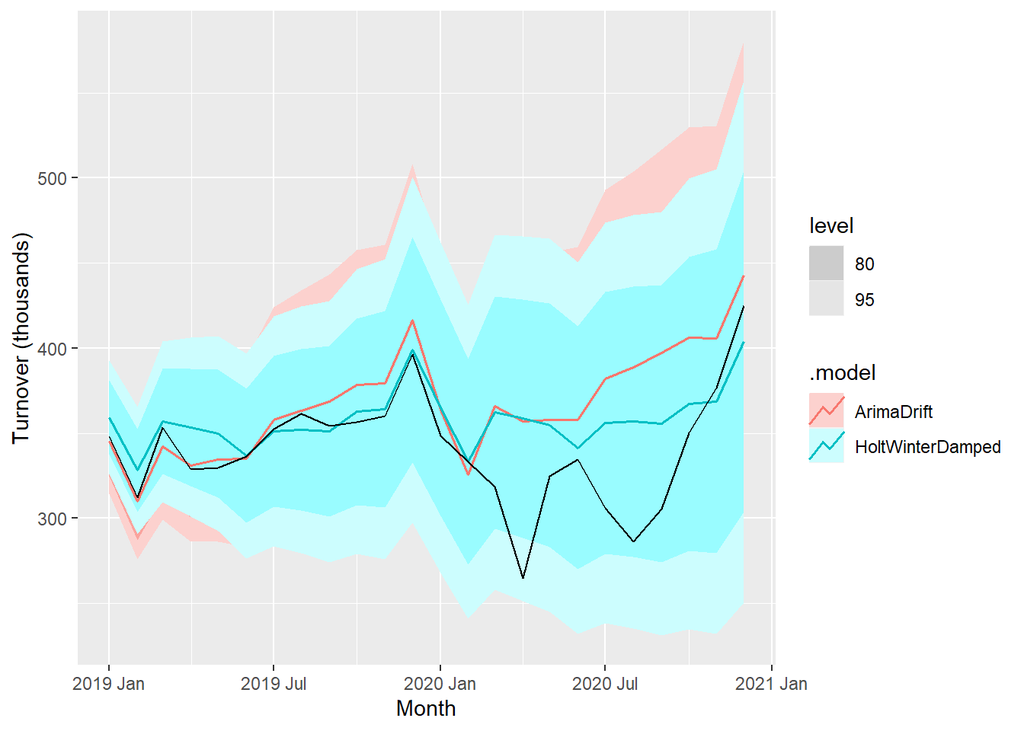

```r
Two_years_forecast |> autoplot(test_set, linewidth = 0.7) + labs(y = "Turnover (thousands)")
```

> The models fit relatively well up until 2020 Jan (when the Covid-19 pandemic started in Australia). Following that, the turnover (black line) drops significantly (possibly due to lockdown or public fear) and remains low (with some spike from lockdown being eased for awhile) until near the end of the year when it rises back up.